# Анализ поведения пользователей мобильного приложения

# Содержание

Краткое описание проекта: стартап продает продукты питания через свое мобильное приложение. Необходимо разобраться в поведении пользователей, изучить воронку продаж. Также необходимо исследовать результат эксперимента по внедрению новых шрифтов в приложение, в рамках которого все пользователи были поделены на 2 контрольные и 1 экспериментальную группы.

Описание данных:

- `EventName` — название события;
- `DeviceIDHash` — уникальный идентификатор пользователя;
- `EventTimestamp` — время события;
- `ExpId` — номер эксперимента: 246 и 247 — контрольные группы, а 248 — экспериментальная.

План исследования:

1. Выгрузка данных и первичное знакомство с данными.
2. Изменение типов данных, обработка дубликатов и пропусков, добавление новых столбцов.
3. Проверка корректности подготовки к проведению A/A/B-теста.
4. Исследование и проверка данных.
5. Изучение воронки событий.
6. Сравнение результатов A/A-теста для контрольных групп.
7. Сравнение результатов A/A/B-теста для экспериментальной и контрольных групп.
8. Принятие решения по результатам A/A/B-теста.
9. Выводы.

Цель проекта: рассмотрение целесообразности изменения шрифтов в мобильном приложении посредством изучения потребительского поведения.

```python
import pandas as pd
import matplotlib.pyplot as plt
import numpy as np
import seaborn as sns
import datetime as dt
import plotly.express as px
from scipy import stats as st
from statsmodels.stats import proportion as pr
from plotly import graph_objects as go
from scipy.stats import binom, norm
from math import sqrt
from IPython.display import display
from IPython.display import Image
```

### Загрузка данных и подготовка к анализу

```python
logs = pd.read_csv('logs_exp.csv', sep = '\t')
```

```python
logs.info()
```

```
<class 'pandas.core.frame.DataFrame'>
RangeIndex: 244126 entries, 0 to 244125
Data columns (total 4 columns):
 #   Column          Non-Null Count   Dtype
---  ------          --------------   -----
 0   EventName       244126 non-null  object
 1   DeviceIDHash    244126 non-null  int64
 2   EventTimestamp  244126 non-null  int64
 3   ExpId           244126 non-null  int64
dtypes: int64(3), object(1)
memory usage: 7.5+ MB
```

### Предобработка данных

#### Замена названий и добавление новых столбцов

```python
logs.columns = ['event', 'user_id', 'timestamp', 'group']
```

```python
logs['datetime'] = logs['timestamp'].map(lambda x: dt.datetime.fromtimestamp(x))
```

```python
logs['dt'] = logs['datetime'].dt.date
logs['dt'] = pd.to_datetime(logs['dt'])
```

#### Обработка пропусков

Из первичного знакомства с данными видно, что пропуски отсутствуют.

#### Обработка дубликатов

```python
print('Количество дубликатов:', logs.duplicated().sum())
print('Доля дубликатов:', round(logs.duplicated().sum()/len(logs)*100,2),'%')
```

```
Количество дубликатов: 413
Доля дубликатов: 0.17 %
```

В данных обнаружено 413 явных дубликатов, что составляет примерно 0,17% от общего количества записей. Поэтому дубликаты лучше удалить.

```python
logs = logs.drop_duplicates()
```

#### Проверка правильности подготовки к A/A/B-тесту

Проверим корректность деления трафика, в идеале пользователей должно быть равное количество в каждой из 3 групп:

```python
logs.groupby(by='group').agg({'user_id': 'nunique'})
```

| group | user_id |
| --- | --- |
| 246 | 2489 |
| 247 | 2520 |
| 248 | 2542 |

```python
print('Относительная разница между группой 248 и 246:',
      round(logs.query('group==248')['user_id'].nunique()/logs.query('group==246')['user_id'].nunique()*100-100, 2), '%')
```

```
Относительная разница между группой 248 и 246: 2.13 %
```

Из результатов проверки видно, что в каждой из групп количество пользователей отличается, но не сильно. Максимальное отличие составляет 53 пользователя или примерно 2.13%. В целом деление трафика можно считать равномерным.

Проверим, есть ли в данных пользователи, которые числятся в 2 или 3 группах сразу:

```python
logs.groupby(by='user_id', as_index=False).agg({'group': 'nunique'}).query('group>1')['user_id'].nunique()
```

```
0
```

Каждый из пользователей входит только в одну группу.

Предобработка данных показала, что данные довольно высокого качества, в них нет пропусков, 0,17% являются дубликатами, которые пришлось удалить.  
Подготовка к проведению A/A/B-теста также была выполнена правильно, в целом выборка поделена на группы равномерно (по количеству пользователей группы отличаются друг от друг на 1-2%), а пользователей, которые состояли бы в нескольких группах, нет.

### Исследование и проверка данных

```python
print('Количество уникальных событий:', logs['event'].nunique())
print('Количество уникальных пользователей:', logs['user_id'].nunique())
```

```
Количество уникальных событий: 5
Количество уникальных пользователей: 7551
```

```python
event_df = logs.groupby(by='user_id').agg({'event': ['nunique', 'count']}).droplevel(1, axis=1)
event_df.columns = ['nunique', 'count']
```

Проверим, есть ли в данных о событиях и действиях выбросы:

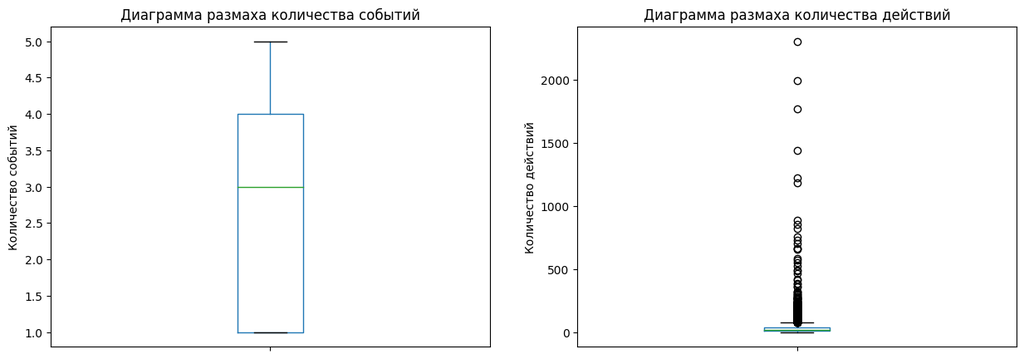

```python
ax1 = event_df['nunique'].plot(kind='box', ax=plt.subplot(1,2,1), figsize=(15,5))
ax1.set(xticklabels=[])
ax1.set_ylabel('Количество событий')
ax1.set_title('Диаграмма размаха количества событий')
ax2 = event_df['count'].plot(kind='box', ax=plt.subplot(1,2,2), figsize=(15,5))
ax2.set(xticklabels=[])
ax2.set_ylabel('Количество действий')
ax2.set_title('Диаграмма размаха количества действий')
plt.show()
```

В данных о событиях выбросов нет, а в данных о действиях есть большое количество пользователей с аномально высокими показателями посещения мобильного приложения. Поэтому в случае с количеством событий можно ориентироваться на среднее количество, а для действий лучше использовать медианы для нивелирования влияния выбросов.

```python
print('Среднее уникальных событий на пользователя:',
      round(event_df['nunique'].mean(),2))
print('Среднее действий, совершаемых одним пользователем:',
      round(event_df['count'].mean(),2))
```

```
Среднее уникальных событий на пользователя: 2.67
Среднее действий, совершаемых одним пользователем: 32.28
```

В логе всего бывает 5 разных видов событий, а уникальных пользователей всего 7551. На каждого пользователя в среднем приходится 2.67 события, а всего действий в среднем каждый пользователь совершает примерно 32.28.

```python
print('Медиана уникальных событий на пользователя:',
      round(event_df['nunique'].median(),2))
print('Медиана действий, совершаемых одним пользователем:',
      round(event_df['count'].median(),2))
```

```
Медиана уникальных событий на пользователя: 3.0
Медиана действий, совершаемых одним пользователем: 20.0
```

Медиана количества посещений пользователем равна 3, а медиана действий равна 20. Это подтверждает влияние выбросов на среднее и медиану: для событий медиана от среднего отличается несильно (3 против 2.67), а для действий отличие большое (20 против 32.28).

```python
print('Дата начала периода:', logs['dt'].min().strftime('%Y-%m-%d'))
print('Дата окончания периода:', logs['dt'].max().strftime('%Y-%m-%d'))
```

```
Дата начала периода: 2019-07-25
Дата окончания периода: 2019-08-08
```

```python
event_count = logs.pivot_table(index='dt', columns='group', values='event', aggfunc='count')
```

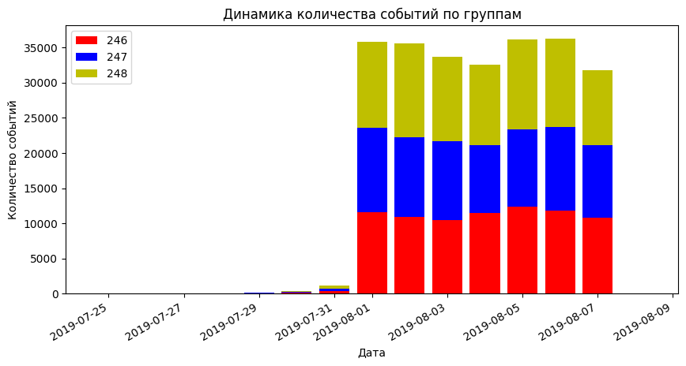

```python
fig, ax = plt.subplots(figsize=(10,5))
ax.bar(event_count.index, event_count[246], color='r', label=246)
ax.bar(event_count.index, event_count[247], bottom=event_count[246], color='b', label=247)
ax.bar(event_count.index, event_count[248], bottom=event_count[246]+event_count[247], color='y', label=248)
ax.xaxis_date()
ax.set_xlabel('Дата')
ax.set_ylabel('Количество событий')
ax.set_title('Динамика количества событий по группам')
fig.autofmt_xdate()
plt.legend()
plt.show()
```

На столбчатой диаграмме видно, что до 31 июля включительно данных в логе намного меньше, чем после 31 июля. Соответственно данные до 1 августа необходимо отбросить и рассматривать период с 1 по 7 августа включительно. На графике также четко видно, что в выборке остаются пользователи из всех 3 экспериментальных групп.

```python
logs_new=logs[logs['dt']>='2019-08-01']
```

```python
print('Количество удаленных из лога записей:', len(logs)-len(logs_new))
print('Доля удаленных из лога записей:', round((len(logs)-len(logs_new))/len(logs)*100,2), '%')
```

```
Количество удаленных из лога записей: 1989
Доля удаленных из лога записей: 0.82 %
```

```python
print('Количество удаленных из лога пользователей:', logs['user_id'].nunique()-logs_new['user_id'].nunique())
print('Доля удаленных из лога пользователей:',
      round((logs['user_id'].nunique()-logs_new['user_id'].nunique())/logs['user_id'].nunique()*100,2), '%')
```

```
Количество удаленных из лога пользователей: 13
Доля удаленных из лога пользователей: 0.17 %
```

Из лога было удалено 1989 записей, что составляет лишь 0,82% от общего количества всех событий. А пользователей было потеряно 13, что составляет 0,17% от общего количества пользователей в данных. Это еще раз подтверждает, что в отброшенном периоде данные неполные и их настолько мало, что лучше их убрать.

### Изучение воронки событий

#### Построение цепочки событий

```python
events_df = logs_new.groupby('event').agg({'user_id':['count', 'nunique']}).droplevel(1, axis=1)
events_df.columns = ['total', 'user_cnt']
events_df['conversion'] = round(events_df['user_cnt']/logs_new['user_id'].nunique()*100,2)
```

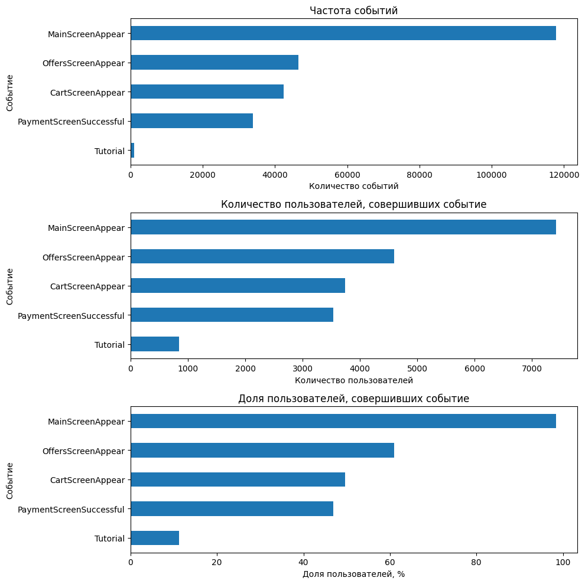

```python
ax = events_df.sort_values(by='total')['total'].plot(kind='barh', figsize=(10,10), ax=plt.subplot(3,1,1))
ax.set_xlabel('Количество событий')
ax.set_ylabel('Событие')
ax.set_title('Частота событий')
ax1 = events_df.sort_values(by='total')['user_cnt'].plot(kind='barh', figsize=(10,10), ax=plt.subplot(3,1,2))
ax1.set_xlabel('Количество пользователей')
ax1.set_ylabel('Событие')
ax1.set_title('Количество пользователей, совершивших событие')
ax2 = events_df.sort_values(by='total')['conversion'].plot(kind='barh', figsize=(10,10), ax=plt.subplot(3,1,3))
ax2.set_xlabel('Доля пользователей, %')
ax2.set_ylabel('Событие')
ax2.set_title('Доля пользователей, совершивших событие')
plt.tight_layout()
plt.show()
```

```python
events_df = events_df.sort_values(by='total', ascending=False)
events_df
```

| event | total | user_cnt | conversion |
| --- | --- | --- | --- |
| MainScreenAppear | 117889 | 7423 | 98.47 |
| OffersScreenAppear | 46531 | 4597 | 60.98 |
| CartScreenAppear | 42343 | 3736 | 49.56 |
| PaymentScreenSuccessful | 33951 | 3540 | 46.96 |
| Tutorial | 1010 | 843 | 11.18 |

На построенных графиках видно, что самым популярным событием является переход на главную страницу, оно встречается чаще всего (117 889 раз) и 98,47% пользователей прошли через этот этап. Далее следуют страница с предложениями (46 531 раз и 60,98% пользователей), страница с корзиной (42 343 раза и 49,56% пользователей) и страница с успешной оплатой (33 951 раз и 46,96% пользователей). Получившаяся на данных последовательность подтверждает логику работы интернет-магазина, поэтому есть основание предположить, что события выстраиваются в цепочку именно таким образом.  
Выбивается из общей последовательности страница с обучением, которая является наименее популярной и сильно уступает всем остальным страницам по всем показателям (1 010 раз и 11,18% пользователей). Однако вряд ли причиной столь редкого посещения страницы с обучением является ее посещение после усешной покупки. Очевидно, причина в том, что крайне мало пользователей проходит обучение перед использованием приложения. Соответственно при расчете воронки это событие учитывать не будем.

#### Расчет воронки

```python
events_df['funnel'] = round((events_df['user_cnt'].pct_change() + 1)*100,2)
```

```python
funnel_df = events_df[events_df.index!='Tutorial']
funnel_df.index=['Основная страница', 'Предложения', 'Корзина', 'Успешный платеж']
funnel_df
```

|  | total | user_cnt | conversion | funnel |
| --- | --- | --- | --- | --- |
| Основная страница | 117889 | 7423 | 98.47 | NaN |
| Предложения | 46531 | 4597 | 60.98 | 61.93 |
| Корзина | 42343 | 3736 | 49.56 | 81.27 |
| Успешный платеж | 33951 | 3540 | 46.96 | 94.75 |

```python
fig = go.Figure(go.Funnel(
    y = funnel_df.index,
    x = funnel_df['user_cnt'],
    textposition = "inside",
    textinfo = "value+percent previous",
    ))
fig.update_layout(title={
        'text': "Пользовательская воронка событий",
        'y': 0.9,
        'x': 0.53})
fig.show()
```

[interactive chart not shown]

На графике видно, что больше всего пользователей теряется при переходе от основной страницы к странице с предложениями товара (62% пользователей переходят на нее). То есть примерно треть пользователей посещает главную страницу сайта, а затем уходит.  
Примерно 81% пользователей, просматривавших предложения товара, добавляют его в корзину. Логично, что эта доля выше, чем при переходе от основной страницы к предложениям, так как если пользователь просматривает предложения товара, то он уже действительно задумался о покупке и вероятно найдет то, что ему нужно.  
95% пользователей, добавивших товар в корзину, успешно оплатили его. Если пользователь при выборе товара добавил его в корзину, то вероятность того, что товар он не купит, крайне мала.  
В целом до успешной оплаты товара доходят примерно 47,7% пользователей, посетивших основную страницу, что является очень хорошим показателем конверсии посетителя в покупателя.  
Также необходимо еще раз отметить, что, например, не все пользователи заходили на основную страницу (98,47% заходили). Это означает, что какие-то пользователи перешли сразу на другой этап, скорее всего на страницу с предложением товара. То есть при расчете воронки есть некоторая погрешность, однако ей можно пренебречь, так как большинство пользователей проходят именно через этот путь.

Из анализа данных о событиях следует, что в логе четко прослеживается определенная цепочка событий. При этом больше всего пользователей (38%) теряется при переходе с основной страницы на страницу с товаром, а до платежа доходят 47,7% (или 47% от общего количества) пользователей, что является очень высоким показателем конверсии посетителя в покупателя. Также стоит отметить, что не все пользователи проходят через рассмотренную воронку, однако процент непроходящих пользователей очень мал (например на основной странице побывали 98,47% всех пользователей).

### Изучение результатов A/A/B-теста

```python
logs_new.groupby(by='group').agg({'user_id':'nunique'})
```

| group | user_id |
| --- | --- |
| 246 | 2484 |
| 247 | 2517 |
| 248 | 2537 |

#### Выбор уровня значимости с учетом множественности проверок

Для того чтобы выбрать правильный уровень значимости с учетом множественности проверок, необходимо определиться с количеством проверяемых на одних и тех же данных гипотез. Что касается гипотез о долях, то их необходимо проверить попарно для каждого события и каждой группы. Вариантов с группами всего 4 (A1 и A2; A1 и B; A2 и B; (A1+A2) и B), а событий всего 5. Поэтому гипотез с долями всего будет 5 * 4 = 20.  
Для лучшей проверки контрольных групп A1 и A2 можно также сравнить их средние количества событий и действий, совершаемых пользователями, а также средние времени, в которое пользователи предпочитают заходить на сайт. Это еще 3 проверки. Таким образом, общее количество проверок на одних и тех же данных составляет 23.

Поправка Бонферрони силнее всего снижает мощность теста.  
Поправка Холма и иные пошаговые методы являются наиболее подходящими с точки зрения мощности теста методами, однако в силу более сложного расчета уровня значимости и необходимости ранжирования гипотез по возрастанию p-value использование данного метода оправдано лишь в случае спорных значений p-value.  
Поэтому для первого тестирования всех гипотез лушче всего использовать поправку Шидака, так как она меньше Бонферрони снижает мощность теста, а уровень значимости одинаков для всех проверок в отличие от метода Холма. Возьмем базовый уровень значимости равным 0.05. Тогда с учетом поправки и количества гипотез уровень значимости получается равным следующему числу:

```python
alpha = 0.05
m = 23
alpha_new = 1-(1-alpha)**(1/m)
print('Уровень значимости:', round(alpha_new,4))
```

```
Уровень значимости: 0.0022
```

#### Проверка контрольных групп A/A

```python
sampleA1 = logs_new[logs_new['group'] == 246].groupby(by='user_id').agg({'event':['nunique', 'count']})
sampleA2 = logs_new[logs_new['group'] == 247].groupby(by='user_id').agg({'event':['nunique', 'count']})
sampleA1 = sampleA1.droplevel(1,axis=1)
sampleA2 = sampleA2.droplevel(1,axis=1)
sampleA1.columns = ['unique', 'total']
sampleA2.columns = ['unique', 'total']
```

##### Среднее количество действий

Сформулируем гипотезы:  
H0: Средние количества действий по пользователям в группах 246 и 247 равны.  
H1: Средние количества действий по пользователям в группах 246 и 247 не равны.

Проверим нормальность распределения данных для количества действий с помощью гистограмм и теста Шапиро-Уилка.

Избавимся от аномалий, отбросим данные после 95-ого перцентиля.

```python
percA1 = np.percentile(sampleA1['total'], [90,95,99])
percA2 = np.percentile(sampleA2['total'], [90,95,99])
```

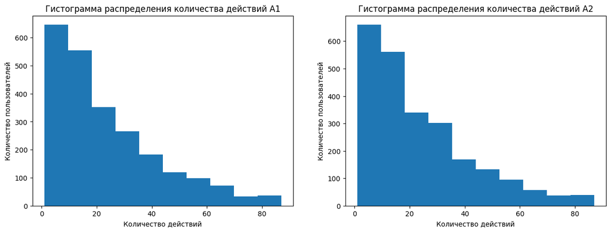

```python
ax = sampleA1[sampleA1['total']<=percA1[1]]['total'].plot(kind='hist', figsize=(10,5), ax=plt.subplot(1,2,1))
ax.set_xlabel('Количество действий')
ax.set_ylabel('Количество пользователей')
ax.set_title('Гистограмма распределения количества действий A1')
ax1 = sampleA2[sampleA2['total']<=percA2[1]]['total'].plot(kind='hist', figsize=(15,5), ax=plt.subplot(1,2,2))
ax1.set_xlabel('Количество действий')
ax1.set_ylabel('Количество пользователей')
ax1.set_title('Гистограмма распределения количества действий A2')
plt.show()
```

```python
print('A1:', st.shapiro(sampleA1[sampleA1['total']<=percA1[1]]['total']))
print('A2:', st.shapiro(sampleA2[sampleA2['total']<=percA2[1]]['total']))
```

```
A1: ShapiroResult(statistic=0.8910079598426819, pvalue=5.833091510707499e-38)
A2: ShapiroResult(statistic=0.8850290775299072, pvalue=5.980629741861173e-39)
```

Обе контрольные группы распределены ненормально. На гистограмме четко видно, что чем меньше количество действий, тем больше пользователей в каждой из выборок. Из теста Шапиро-Уилка также следует вывод, что гипотезу о нормальности отклоняем (p-value < 0.0022 для каждой выборки).  
Таким образом, для проверки гипотезы о равенстве средних следует применять непараметрический тест Манна-Уитни.

```python
print('p-value:', '{0:.5f}'.format(st.mannwhitneyu(sampleA1['total'], sampleA2['total'])[1]))
print('Относительная разница среднего количества действий A1 к A2:',
      '{0:.1f}'.format((sampleA2['total'].mean()/sampleA1['total'].mean()-1)*100))
```

```
p-value: 0.80661
Относительная разница среднего количества действий A1 к A2: -4.1
```

```python
print('p-value:', '{0:.5f}'.format(st.mannwhitneyu(sampleA1[sampleA1['total']<=percA1[1]]['total'],
                                                   sampleA2[sampleA2['total']<=percA2[1]]['total'])[1]))
print('Относительная разница среднего количества действий A1 к A2:',
      '{0:.1f}'.format((sampleA2[sampleA2['total']<=percA2[1]]['total'].mean()/
                       sampleA1[sampleA1['total']<=percA1[1]]['total'].mean()-1)*100))
```

```
p-value: 0.83474
Относительная разница среднего количества действий A1 к A2: -0.7
```

Как с учетом выбросов, так и без них получаем, что разница между выборками (4,1% с аномалиями и 0,7% без учета аномалий) не является статистически значимой (p-value > 0.0022). Поэтому по количеству действий существенной разницы между контрольными группами нет. Это также подтверждается распределением данных на гистограммах.

##### Среднее количество событий

Сформулируем гипотезы:  
H0: Средние количества событий по пользователям в группах 246 и 247 равны.  
H1: Средние количества событий по пользователям в группах 246 и 247 не равны.

Проверим нормальность распределения данных для количества действий с помощью гистограмм и теста Шапиро-Уилка.

Посмотрим, есть ли аномалии:

```python
print('A1:', np.percentile(sampleA1['unique'], [90,95,99]))
print('A2:', np.percentile(sampleA2['unique'], [90,95,99]))
```

```
A1: [4. 5. 5.]
A2: [4. 5. 5.]
```

95-й перцентиль равен 5 событиям (максимально возможное число), поэтому аномалий в данных нет.

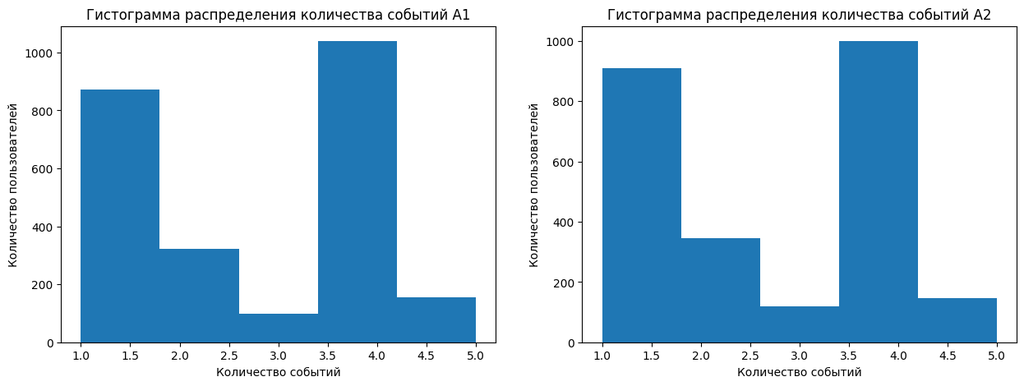

```python
ax = sampleA1['unique'].plot(kind='hist', figsize=(10,5), ax=plt.subplot(1,2,1), bins=5)
ax.set_xlabel('Количество событий')
ax.set_ylabel('Количество пользователей')
ax.set_title('Гистограмма распределения количества событий A1')
ax1 = sampleA2['unique'].plot(kind='hist', figsize=(15,5), ax=plt.subplot(1,2,2), bins=5)
ax1.set_xlabel('Количество событий')
ax1.set_ylabel('Количество пользователей')
ax1.set_title('Гистограмма распределения количества событий A2')
plt.show()
```

```python
print('A1:', st.shapiro(sampleA1[sampleA1['unique']<=percA1[1]]['unique']))
print('A2:', st.shapiro(sampleA2[sampleA2['unique']<=percA2[1]]['unique']))
```

```
A1: ShapiroResult(statistic=0.7864741086959839, pvalue=0.0)
A2: ShapiroResult(statistic=0.7911558151245117, pvalue=0.0)
```

Обе контрольные группы распределены ненормально. На гистограмме четко видно, что распределение не напоминает "колокол". Из теста Шапиро-Уилка также следует вывод, что гипотезу о нормальности отклоняем (p-value < 0.0022 для каждой выборки).  
Таким образом, для проверки гипотезы о равенстве средних следует применять непараметрический тест Манна-Уитни.

```python
print('p-value:', '{0:.5f}'.format(st.mannwhitneyu(sampleA1['unique'], sampleA2['unique'])[1]))
print('Относительная разница среднего количества действий A1 к A2:',
      '{0:.1f}'.format((sampleA2['unique'].mean()/sampleA1['unique'].mean()-1)*100))
```

```
p-value: 0.17196
Относительная разница среднего количества действий A1 к A2: -2.1
```

Получаем, что разница между выборками в 2% не является статистически значимой (p-value > 0.0022). Поэтому по количеству событий существенной разницы между контрольными группами нет. Это также подтверждается распределением данных на гистограммах.

##### Среднее время посещения сайта

Сформулируем гипотезы:  
H0: Среднее время посещения сайта в группах 246 и 247 одинаковое.  
H1: Среднее время посещения сайта в группах 246 и 247 разное.

Проверим нормальность распределения данных для количества действий с помощью гистограмм и теста Шапиро-Уилка. Для расчетов возьмем время в секундах в формате timestamp.

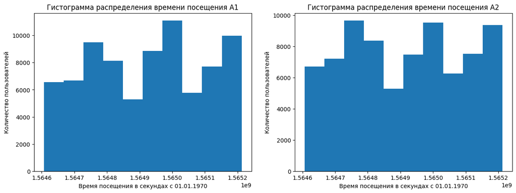

```python
ax = logs_new[logs_new['group']==246]['timestamp'].plot(kind='hist', figsize=(10,5), ax=plt.subplot(1,2,1))
ax.set_xlabel('Время посещения в секундах с 01.01.1970')
ax.set_ylabel('Количество пользователей')
ax.set_title('Гистограмма распределения времени посещения A1')
ax1 = logs_new[logs_new['group']==247]['timestamp'].plot(kind='hist', figsize=(15,5), ax=plt.subplot(1,2,2))
ax1.set_xlabel('Время посещения в секундах с 01.01.1970')
ax1.set_ylabel('Количество пользователей')
ax1.set_title('Гистограмма распределения времени посещения A2')
plt.show()
```

```python
print('A1:', st.shapiro(logs_new[logs_new['group']==246]['timestamp']))
print('A2:', st.shapiro(logs_new[logs_new['group']==247]['timestamp']))
```

```
A1: ShapiroResult(statistic=0.03165018558502197, pvalue=0.0)
A2: ShapiroResult(statistic=0.021876096725463867, pvalue=0.0)
```

Обе контрольные группы распределены ненормально. На гистограмме четко видно, что распределение не напоминает "колокол". Из теста Шапиро-Уилка также следует вывод, что гипотезу о нормальности отклоняем (p-value < 0.0022 для каждой выборки).  
Таким образом, для проверки гипотезы о равенстве средних следует применять непараметрический тест Манна-Уитни.

```python
print('p-value:', '{0:.15f}'.format(st.mannwhitneyu(logs_new[logs_new['group']==246]['timestamp'],
                                                   logs_new[logs_new['group']==247]['timestamp'])[1]))
print('Относительная разница времени посещения A2 к A1:',
      '{0:.7f}'.format((logs_new[logs_new['group']==247]['timestamp'].mean()/
                       logs_new[logs_new['group']==246]['timestamp'].mean()-1)*100))
```

```
p-value: 0.000000000000013
Относительная разница времени посещения A2 к A1: -0.0004352
```

По времени посещения разница очень маленькая (0.00044%). Объясняется это скорее всего тем, что время исчисляется в миллиардах секунд, и соответственно разница в несколько секунд в относительном выражении будет крайне мала. Однако при этом она является статистически значимой (p-value < 0.0022).  
Если обратиться к гистограммам распределения данных, то на них заметно, что пользователи распределны похожим образом. Среди отличий можно лишь отметить, что лидерство времени, которое примерно приходится на 5 августа (1.5650e^9) в группе A1 выражено более ярко, чем в группе А2.  
Результат теста скорее всего обусловлен большим количеством наблюдений и их повышенной чувствительностью к небольшим различиям. На гистограмме очень хорошо видно, что на самом деле по времени посещения сайта выборки мало чем отличаются друг от друга.

##### Доли совершивших события

Сформулируем гипотезы:  
H0: Доли совершивших события в контрольных группах 246 и 247 равны.  
H1: Доли совершивших события в контрольных группах 246 и 247 разные.

Проверять гипотезы будем с помощью z-теста.

```python
def z_testing(df, alpha):
    for row in range(len(df)):
        p_value = pr.proportions_ztest([df.loc[row, 'success1'], df.loc[row, 'success2']], [df.loc[row, 'trial1'], df.loc[row, 'trial2']])[1]
        print(df.loc[row, 'event'], 'p-значение:', round(p_value,5))
        if p_value < alpha:
            print('Отвергаем нулевую гипотезу: между долями есть значимая разница')
        else:
            print('Не получилось отвергнуть нулевую гипотезу, нет оснований считать доли разными')
    return
```

```python
def df_creater(group1, group2, group3):
    df = logs_new[logs_new['group']!=group1].pivot_table(index='event', values='user_id', columns='group', aggfunc='nunique')
    df.columns = ['success1', 'success2']
    df['trial1'] = logs_new[logs_new['group']==group2]['user_id'].nunique()
    df['trial2'] = logs_new[logs_new['group']==group3]['user_id'].nunique()
    df['conversion1'] = round(df['success1']/df['trial1']*100,2)
    df['conversion2'] = round(df['success2']/df['trial2']*100,2)
    df = df.sort_values(by='success1', ascending = False).reset_index()
    return df
```

```python
def bar_creater(df):
    n = len(df)
    r = np.arange(n)
    width = 0.25
    fig,ax = plt.subplots(figsize=(15,8))
    ax=plt.bar(r, df['conversion1'], width=width, label='conversion1')
    ax=plt.bar(r + width, df['conversion2'], width=width, label='conversion2')
    plt.xlabel('Событие')
    plt.ylabel('Конверсия, %')
    plt.title('Конверсия в события по группам')
    plt.xticks(r + width/2, df['event'])
    plt.legend()
    for x,y in zip(r, df['conversion1']):

        label = "{:.2f}".format(y)

        plt.annotate(label,
                    (x, y),
                    textcoords="offset points",
                    xytext=(0,5),
                    ha='center')
    for x,y in zip(r + width, df['conversion2']):

        label = "{:.2f}".format(y)

        plt.annotate(label,
                     (x, y),
                     textcoords="offset points",
                     xytext=(0,5),
                     ha='center')
    plt.show()
    return
```

```python
aa_test = df_creater(248, 246, 247)
aa_test
```

|  | event | success1 | success2 | trial1 | trial2 | conversion1 | conversion2 |
| --- | --- | --- | --- | --- | --- | --- | --- |
| 0 | MainScreenAppear | 2450 | 2479 | 2484 | 2517 | 98.63 | 98.49 |
| 1 | OffersScreenAppear | 1542 | 1524 | 2484 | 2517 | 62.08 | 60.55 |
| 2 | CartScreenAppear | 1266 | 1239 | 2484 | 2517 | 50.97 | 49.23 |
| 3 | PaymentScreenSuccessful | 1200 | 1158 | 2484 | 2517 | 48.31 | 46.01 |
| 4 | Tutorial | 278 | 284 | 2484 | 2517 | 11.19 | 11.28 |

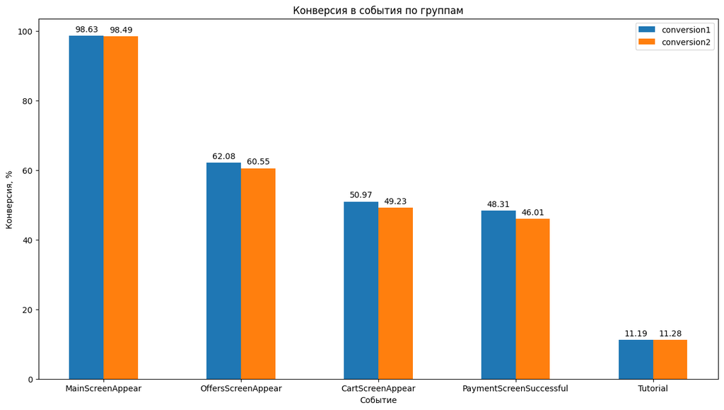

```python
aa_conversion = bar_creater(aa_test)
```

```python
z_testing(aa_test, alpha_new)
```

```
MainScreenAppear p-значение: 0.67562
Не получилось отвергнуть нулевую гипотезу, нет оснований считать доли разными
OffersScreenAppear p-значение: 0.26699
Не получилось отвергнуть нулевую гипотезу, нет оснований считать доли разными
CartScreenAppear p-значение: 0.21828
Не получилось отвергнуть нулевую гипотезу, нет оснований считать доли разными
PaymentScreenSuccessful p-значение: 0.10298
Не получилось отвергнуть нулевую гипотезу, нет оснований считать доли разными
Tutorial p-значение: 0.91828
Не получилось отвергнуть нулевую гипотезу, нет оснований считать доли разными
```

Все проведенные тесты показали, что контрольные группы 246 и 247 почти неотличимы друг от друга.  
Отдельно стоит отметить, что на данный вывод не влияет выбор уровня значимости. Даже при alpha=0.05 все равно p-value > alpha по всем тестам, кроме времени посещения сайта, которое тем не менее все равно распределено примерно одинаково (это заметно на гистограммах распределения).  
Таким образом, разбиение на контрольные группы работает корректно.

#### Сравнение долей соверших события в экспериментальной группе с контрольными

Для удобства в использовании функций возьмем контрольную группу за 1, а экспериментальную за 2.

##### Сравнение долей совершивших события в группах 248 и 246

```python
a1b_test = df_creater(247, 246, 248)
a1b_test
```

|  | event | success1 | success2 | trial1 | trial2 | conversion1 | conversion2 |
| --- | --- | --- | --- | --- | --- | --- | --- |
| 0 | MainScreenAppear | 2450 | 2494 | 2484 | 2537 | 98.63 | 98.31 |
| 1 | OffersScreenAppear | 1542 | 1531 | 2484 | 2537 | 62.08 | 60.35 |
| 2 | CartScreenAppear | 1266 | 1231 | 2484 | 2537 | 50.97 | 48.52 |
| 3 | PaymentScreenSuccessful | 1200 | 1182 | 2484 | 2537 | 48.31 | 46.59 |
| 4 | Tutorial | 278 | 281 | 2484 | 2537 | 11.19 | 11.08 |

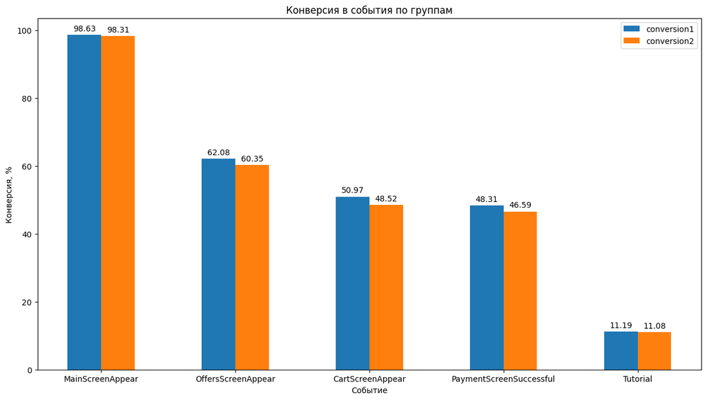

```python
a1b_conversion = bar_creater(a1b_test)
```

```python
z_testing(a1b_test, alpha_new)
```

```
MainScreenAppear p-значение: 0.34706
Не получилось отвергнуть нулевую гипотезу, нет оснований считать доли разными
OffersScreenAppear p-значение: 0.20836
Не получилось отвергнуть нулевую гипотезу, нет оснований считать доли разными
CartScreenAppear p-значение: 0.08328
Не получилось отвергнуть нулевую гипотезу, нет оснований считать доли разными
PaymentScreenSuccessful p-значение: 0.22269
Не получилось отвергнуть нулевую гипотезу, нет оснований считать доли разными
Tutorial p-значение: 0.89645
Не получилось отвергнуть нулевую гипотезу, нет оснований считать доли разными
```

##### Сравнение долей совершивших события в группах 248 и 247

```python
a2b_test = df_creater(246, 247, 248)
a2b_test
```

|  | event | success1 | success2 | trial1 | trial2 | conversion1 | conversion2 |
| --- | --- | --- | --- | --- | --- | --- | --- |
| 0 | MainScreenAppear | 2479 | 2494 | 2517 | 2537 | 98.49 | 98.31 |
| 1 | OffersScreenAppear | 1524 | 1531 | 2517 | 2537 | 60.55 | 60.35 |
| 2 | CartScreenAppear | 1239 | 1231 | 2517 | 2537 | 49.23 | 48.52 |
| 3 | PaymentScreenSuccessful | 1158 | 1182 | 2517 | 2537 | 46.01 | 46.59 |
| 4 | Tutorial | 284 | 281 | 2517 | 2537 | 11.28 | 11.08 |

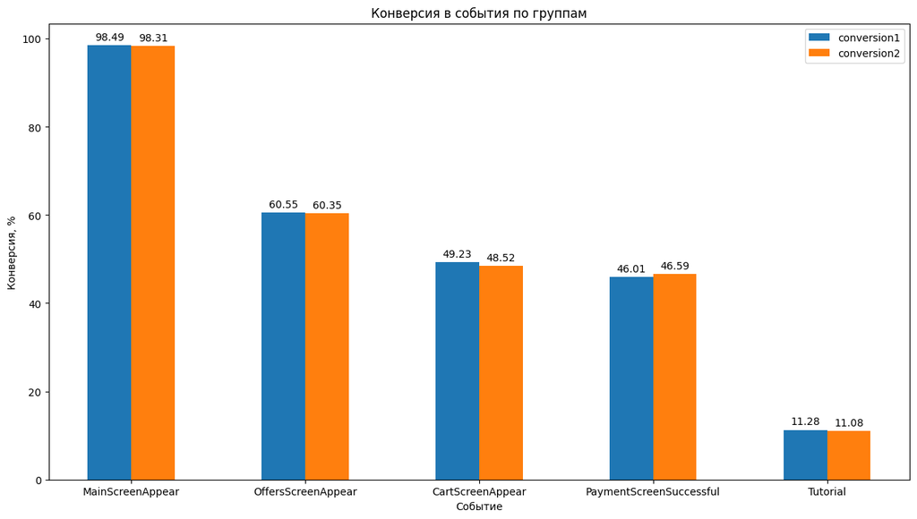

```python
a2b_conversion = bar_creater(a2b_test)
```

```python
z_testing(a2b_test, alpha_new)
```

```
MainScreenAppear p-значение: 0.60017
Не получилось отвергнуть нулевую гипотезу, нет оснований считать доли разными
OffersScreenAppear p-значение: 0.8836
Не получилось отвергнуть нулевую гипотезу, нет оснований считать доли разными
CartScreenAppear p-значение: 0.61695
Не получилось отвергнуть нулевую гипотезу, нет оснований считать доли разными
PaymentScreenSuccessful p-значение: 0.67754
Не получилось отвергнуть нулевую гипотезу, нет оснований считать доли разными
Tutorial p-значение: 0.8152
Не получилось отвергнуть нулевую гипотезу, нет оснований считать доли разными
```

##### Сравнение долей совершивших события в группах 248 и (246+247)

```python
ab_test = logs_new.pivot_table(index='event', values='user_id', columns='group', aggfunc='nunique')
ab_test['246+247'] = ab_test[246] + ab_test[247]
ab_test = ab_test.drop(columns=[246, 247])
ab_test.columns = ['success2', 'success1']
ab_test['trial2'] = logs_new[logs_new['group']==248]['user_id'].nunique()
ab_test['trial1'] = logs_new[logs_new['group']!=248]['user_id'].nunique()
ab_test['conversion2'] = round(ab_test['success2']/ab_test['trial2']*100,2)
ab_test['conversion1'] = round(ab_test['success1']/ab_test['trial1']*100,2)
ab_test = ab_test.sort_values(by='success2', ascending = False).reset_index()
ab_test
```

|  | event | success2 | success1 | trial2 | trial1 | conversion2 | conversion1 |
| --- | --- | --- | --- | --- | --- | --- | --- |
| 0 | MainScreenAppear | 2494 | 4929 | 2537 | 5001 | 98.31 | 98.56 |
| 1 | OffersScreenAppear | 1531 | 3066 | 2537 | 5001 | 60.35 | 61.31 |
| 2 | CartScreenAppear | 1231 | 2505 | 2537 | 5001 | 48.52 | 50.09 |
| 3 | PaymentScreenSuccessful | 1182 | 2358 | 2537 | 5001 | 46.59 | 47.15 |
| 4 | Tutorial | 281 | 562 | 2537 | 5001 | 11.08 | 11.24 |

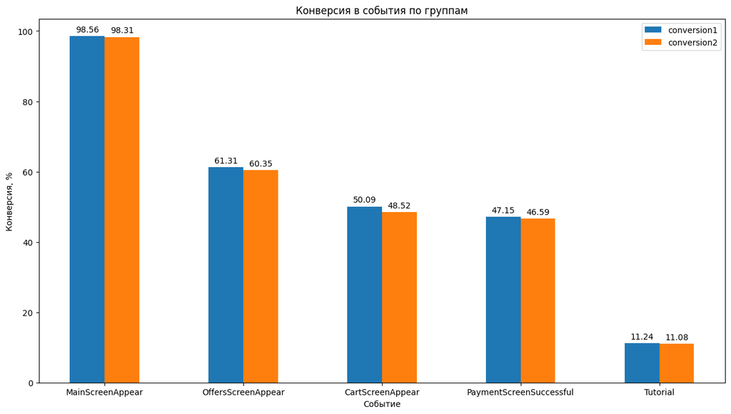

```python
ab_conversion = bar_creater(ab_test)
```

```python
z_testing(ab_test, alpha_new)
```

```
MainScreenAppear p-значение: 0.39299
Не получилось отвергнуть нулевую гипотезу, нет оснований считать доли разными
OffersScreenAppear p-значение: 0.419
Не получилось отвергнуть нулевую гипотезу, нет оснований считать доли разными
CartScreenAppear p-значение: 0.19819
Не получилось отвергнуть нулевую гипотезу, нет оснований считать доли разными
PaymentScreenSuccessful p-значение: 0.64521
Не получилось отвергнуть нулевую гипотезу, нет оснований считать доли разными
Tutorial p-значение: 0.8333
Не получилось отвергнуть нулевую гипотезу, нет оснований считать доли разными
```

#### Решение по результатам A/A/B-теста

Результат A/A/B-теста является однозначным: вводить новый шрифт не нужно, так как это не привело к статистически значимому увеличению конверсии пользователей ни по одному из осуществляемых на сайте событий.  
Единственное выявленное при сравнении групп 248 и 247 увеличение доли покупателей с 46,01% до 46,59% статистически значимым не является. Во всех остальных случаях наблюдается снижение доли покупателей.  
Результаты теста также подтверждают, что использование поправки Холма не имеет смысла, так как p-value по всем гипотезам либо больше 0.05, либо сильно меньше значений, используемых в других непошаговых поправках (например, 0.0022).

### Выводы

- Предобработка данных показала, что представленные в логе данные довольно высокого качества: в них отсутствуют пропуски, а количество явных дубликатов составляет 0,17%, поэтому они были удалены;
- Подготовка к проведениию A/A/B-теста была проведена корректно: выборка поделена на группы равномерно (разница между группами составляет 1-2%), а пользователей, состоящих в 2 или 3 группах сразу, нет;
- В рассматриваемом двухнедельном периоде на каждого пользователя в среднем приходится примерно 2,67 события, а медиана действий равна 20;
- На первую неделю периода приходится всего лишь 0,82% от общего количества данных, что говорит о высокой вероятности их неполноты за данный период, поэтому в целях анализа рассматривалась только вторая половина периода без нарушения равномерного распределения пользователей по группам;
- Пользователь в рамках пользования приложением проходит следующий путь (в скобках указана доля перешедших на данный этап из предыдущего): основная страница -> предложения (62%) -> корзина (81%) -> оплата товара (95%). При этом на основной странице побывали 98,47% пользователей, т.е. не все пользователи проходят данный путь, а до оплаты товара доходили 47% от общего количества пользователей, что является крайне высоким показателем конверсии посетителей в покупателей;
- A/A/B тест показал, что вводить новый шрифт нецелесообразно: почти по всем событиям в результате нововведений конверсия упала (в 14 из 15 случаях), при этом ни один из результатов не является статистически значимым. Контрольные группы были сформированы корректно и A/A тест показал правильность всех механизмов и расчетов в рамках эксперимента.